# Reproducible Research PA1.Rmd

Xiuyi He

August 8, 2015

*Notes:First of all, because my html file is too big to shown in the github website,* *I upload these pictures for viewing and grading.* *Sorry for the inconvenience and thanks a lot!*

**Loading and preprocessing the data**

```r
data <- read.csv("activity.csv")
head(data)
```

```
##   steps       date interval
## 1    NA 2012-10-01        0
## 2    NA 2012-10-01        5
## 3    NA 2012-10-01       10
## 4    NA 2012-10-01       15
## 5    NA 2012-10-01       20
## 6    NA 2012-10-01       25
```

```r
str(data)
```

```
## 'data.frame':    17568 obs. of  3 variables:
##  $ steps   : int  NA NA NA NA NA NA NA NA NA NA ...
##  $ date    : Factor w/ 61 levels "2012-10-01","2012-10-02",..: 1 1 1 1 1 1 1 1 1 1 ...
##  $ interval: int  0 5 10 15 20 25 30 35 40 45 ...
```

**What is mean total number of steps taken per day?**

1.Calculate the total number of steps taken per day

```r
tapply(data$steps,data$date,sum)
```

```
## 2012-10-01 2012-10-02 2012-10-03 2012-10-04 2012-10-05 2012-10-06
##         NA        126      11352      12116      13294      15420
## 2012-10-07 2012-10-08 2012-10-09 2012-10-10 2012-10-11 2012-10-12
##      11015         NA      12811       9900      10304      17382
## 2012-10-13 2012-10-14 2012-10-15 2012-10-16 2012-10-17 2012-10-18
##      12426      15098      10139      15084      13452      10056
## 2012-10-19 2012-10-20 2012-10-21 2012-10-22 2012-10-23 2012-10-24
##      11829      10395       8821      13460       8918       8355
## 2012-10-25 2012-10-26 2012-10-27 2012-10-28 2012-10-29 2012-10-30
##       2492       6778      10119      11458       5018       9819
## 2012-10-31 2012-11-01 2012-11-02 2012-11-03 2012-11-04 2012-11-05
##      15414         NA      10600      10571         NA      10439
## 2012-11-06 2012-11-07 2012-11-08 2012-11-09 2012-11-10 2012-11-11
##       8334      12883       3219         NA         NA      12608
## 2012-11-12 2012-11-13 2012-11-14 2012-11-15 2012-11-16 2012-11-17
##      10765       7336         NA         41       5441      14339
## 2012-11-18 2012-11-19 2012-11-20 2012-11-21 2012-11-22 2012-11-23
##      15110       8841       4472      12787      20427      21194
## 2012-11-24 2012-11-25 2012-11-26 2012-11-27 2012-11-28 2012-11-29
##      14478      11834      11162      13646      10183       7047
## 2012-11-30
##         NA
```

2.Make a histogram of the total number of steps taken each day

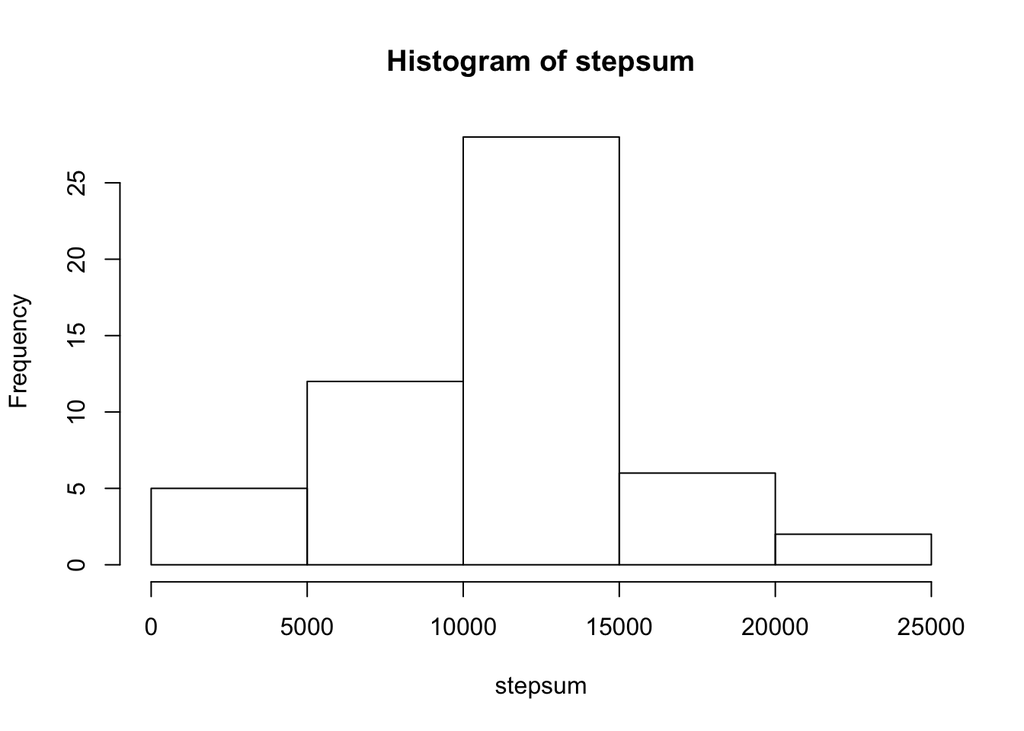

```r
stepsum <- tapply(data$steps,data$date,sum)
hist(stepsum)
```

3.Calculate and report the mean and median of the total number of steps taken per day

```r
mean(stepsum[!is.na(stepsum)])
```

```
## [1] 10766.19
```

```r
median(stepsum[!is.na(stepsum)])
```

```
## [1] 10765
```

**What is the average daily activity pattern?**

1.Make a time series plot (i.e. type = “l”) of the 5-minute interval (x-axis) and the average number of steps taken, averaged across all days (y-axis)

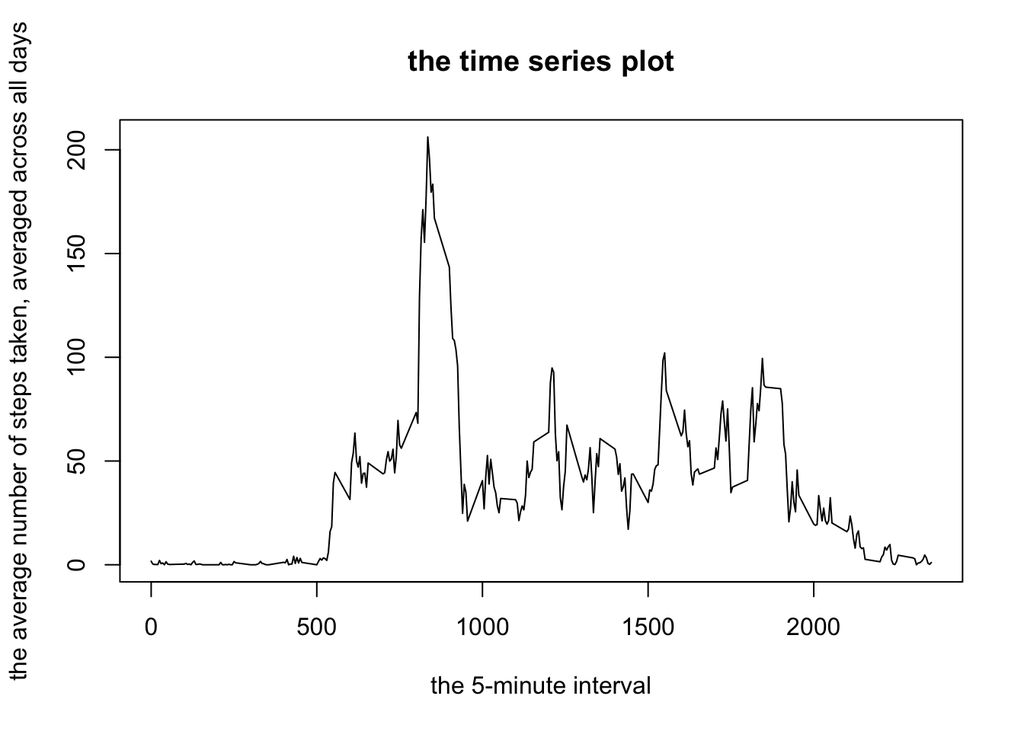

```r
sub <- data[complete.cases(data$steps),]
data$interval <- as.numeric(data$interval)
for(i in 1:17568){
      if(is.na(data$steps[i])){
             data$steps[i] <- mean(sub$steps[sub$interval == data$interval[i]])
       }
 }
meansteps <- tapply(data$steps,data$interval,mean)
data <- read.csv("activity.csv")
interval <- data$interval[1:288]
combine <- data.frame(cbind(interval,meansteps))
plot(combine$interval,combine$meansteps,type="l",xlab="the 5-minute interval",ylab="the average number of steps taken, averaged across all days",main="the time series plot")
```

2.Which 5-minute interval, on average across all the days in the dataset, contains the maximum number of steps?

```r
maxvalue <- max(meansteps)
subcombine <- combine[combine$meansteps==maxvalue,]
subcombine$interval
```

```
## [1] 835
```

The interval that contains max steps is *835*

**Imputing missing values** 1.Calculate and report the total number of missing values in the dataset

```r
length(data$steps[is.na(data$steps)])
```

```
## [1] 2304
```

2.Devise a strategy for filling in all of the missing values in the dataset. I will use the mean of that interval to fill out the NAs

```r
sub <- data[complete.cases(data$steps),]
```

There are *2304* NAs

3.then write a function to fill out the NAs

```r
data$interval <- as.numeric(data$interval)
for(i in 1:17568){
      if(is.na(data$steps[i])){
            data$steps[i] <- mean(sub$steps[sub$interval == data$interval[i]])
      }
}
head(data)
```

```
##       steps       date interval
## 1 1.7169811 2012-10-01        0
## 2 0.3396226 2012-10-01        5
## 3 0.1320755 2012-10-01       10
## 4 0.1509434 2012-10-01       15
## 5 0.0754717 2012-10-01       20
## 6 2.0943396 2012-10-01       25
```

*Replace NAs with mean of the interval*

4.Make a histogram of the total number of steps taken each day and Calculate and report the mean and median total number of steps taken per day.

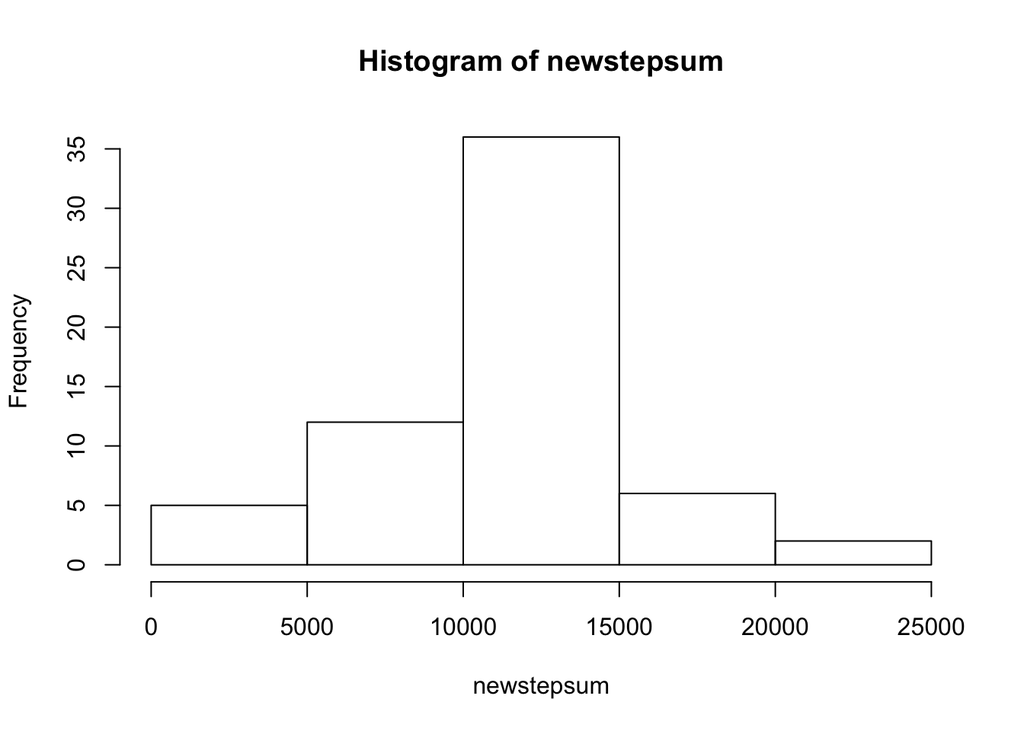

```r
newstepsum <- tapply(data$steps,data$date,sum)
hist(newstepsum)
```

```r
mean(newstepsum)
```

```
## [1] 10766.19
```

```r
median(newstepsum)
```

```
## [1] 10766.19
```

**Are there differences in activity patterns between weekdays and weekends?**

```r
library(dplyr)
library(lubridate)
data1 <- mutate(data,weekday = wday(ymd(data[,2])))
data1$weekday <- as.numeric(data1$weekday)
for(i in 1:17568){
      if(data1[i,4] == 1){
            data1[i,4] <- "weekend"
      }else if (data1[i,4] == 7){
            data1[i,4] <- "weekend"
      }else {
            data1[i,4] <- "weekday"
      }
}
data1$weekday <- as.factor(data1$weekday)
```

the plot

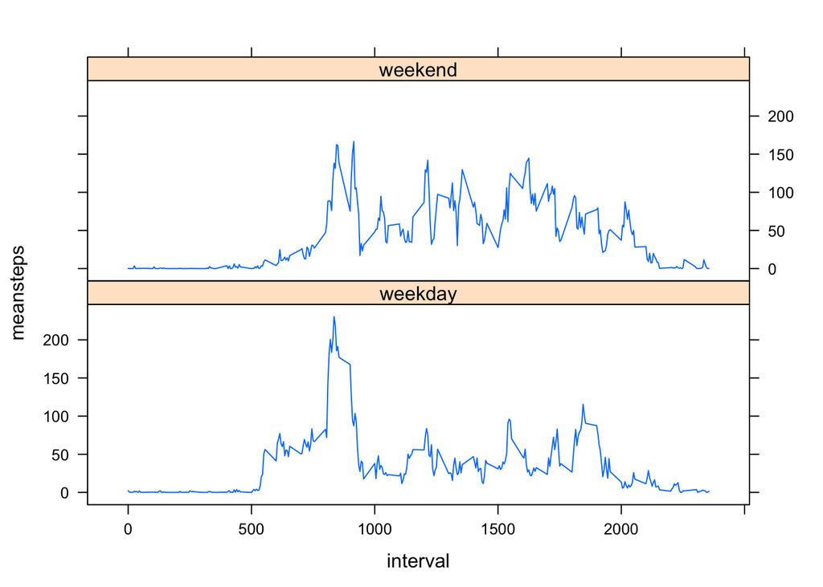

```r
#process the data set
subweekday <- data1[data1$weekday == "weekday",]
subweekend <- data1[data1$weekday == "weekend",]
pweekday <- aggregate(subweekday$steps,by=list(subweekday$interval),FUN=mean)
colnames(pweekday) <- c("interval","meansteps")
pweekday$fweekday <- "weekday"
pweekend <- aggregate(subweekend$steps,by=list(subweekend$interval),FUN=mean)
colnames(pweekend) <- c("interval","meansteps")
pweekend$fweekday <- "weekend"
data2 <- rbind(pweekday,pweekend)


#plot the picture
library(lattice)
xyplot(meansteps~interval|fweekday,data2,type="l",layout=c(1,2))
```